# Dimensional Reduction and Clustering

hongc2@ccf.org

1/16/2020

Load the R environment variable we worked in the previous step,

```r
#load R libraries necessary
library(dplyr)
```

```r
library(Seurat)
library(ggplot2)

load('filtered_gene_bc_matrices/hg19/01_pbmc3k_sctf.rd') #pbmc
```

### Perform linear dimensional reduction

We perform PCA on the scaled data. By default, only the previously determined variable features are used as input but can be defined using the `features` argument if you wish to choose a different subset.

```r
pbmc <- RunPCA(pbmc, verbose = FALSE)
```

Seurat provides several useful ways of visualizing both cells and features that define the PCA, including `VizDimReduction`, `DimPlot`, and `DimHeatmap`.

```r
# Examine and visualize PCA results a few different ways
print(pbmc[["pca"]], dims = 1:5, nfeatures = 5)
```

```
## PC_ 1
## Positive:  FTL, LYZ, FTH1, CST3, S100A9
## Negative:  MALAT1, CCL5, NKG7, RPS27A, LTB
## PC_ 2
## Positive:  NKG7, CCL5, GZMB, GNLY, GZMA
## Negative:  CD74, HLA-DRA, CD79A, HLA-DQA1, HLA-DPB1
## PC_ 3
## Positive:  CD74, HLA-DRA, CD79A, NKG7, HLA-DPB1
## Negative:  S100A8, S100A9, JUNB, RPS12, IL7R
## PC_ 4
## Positive:  S100A8, S100A9, LYZ, LGALS2, CD14
## Negative:  FCGR3A, LST1, FCER1G, AIF1, MS4A7
## PC_ 5
## Positive:  GPX1, CCL5, PPBP, PF4, SDPR
## Negative:  FCGR3A, LST1, GNLY, AIF1, IFITM3
```

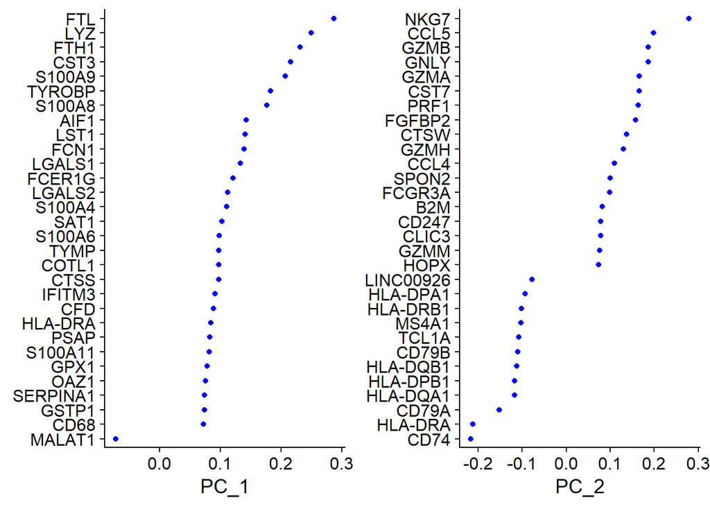

```r
# Load PC1 and PC2 dimension vectors
VizDimLoadings(pbmc, dims = 1:2, reduction = "pca")
```

Plot 2D PCA. Note that the PCA is computed from `SCT` assay.

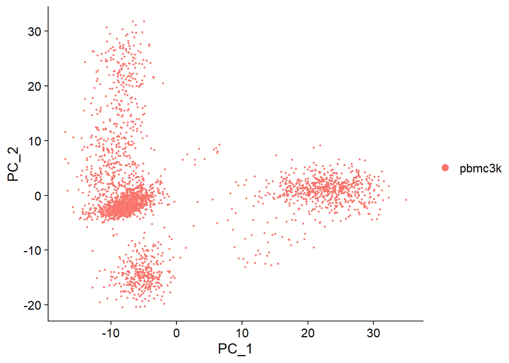

```r
DimPlot(pbmc, reduction = "pca")
```

In particular `DimHeatmap` allows for easy exploration of the primary sources of heterogeneity in a dataset and can be useful when trying to decide which PCs to include for further downstream analyses. Both cells and features are ordered according to their PCA scores. Setting `cells` to a number plots the “extreme” cells on both ends of the spectrum, which dramatically speeds plotting for large datasets. Though a supervised analysis, we find this to be a valuable tool for exploring correlated feature sets.

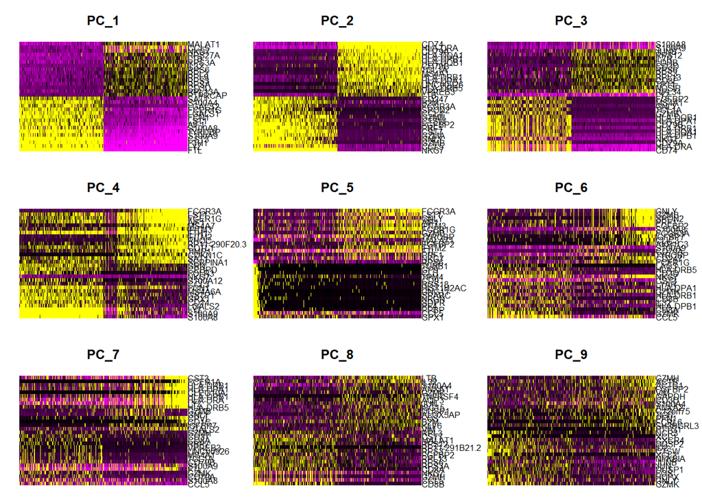

```r
DimHeatmap(pbmc, dims = 1:9, cells = 500, balanced = TRUE)
```

### Determine the “dimensionality” of the dataset

To overcome the extensive technical noise in any single feature for scRNA-seq data, Seurat clusters cells based on their PCA scores, with each PC essentially representing a “meta feature” that combines information across a correlated feature set. The top principal components, therefore, represent a robust compression of the dataset. However, how many components should we choose to include? 10? 20? 100?

We use the “Elbow plot” to determine an appropriate number of dimensions. It plots a ranking of principal components based on the percentage of variance explained by each one (ElbowPlot function). In this example, we can observe an “elbow” around PC9-14, suggesting that the majority of true signal is captured in the first 13 PCs.

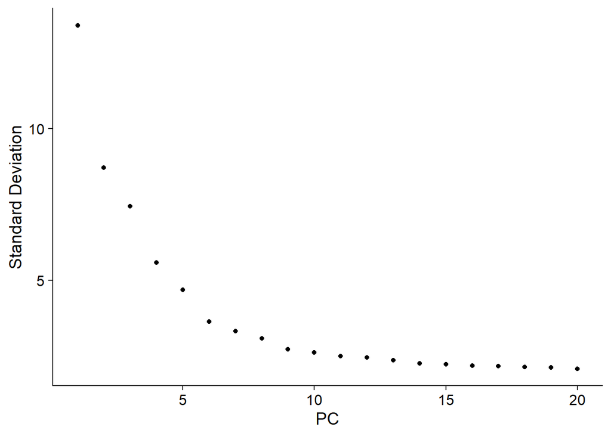

```r
ElbowPlot(pbmc)
```

Identifying the true dimensionality of a dataset can be challenging/uncertain for the user. The examining standard deviation is a heuristic but it is commonly used, and can be calculated instantly. We might have been justified in choosing anything between PC 9-14 as a cutoff.

### Clustering the cells

Seurat v3 applies a graph-based clustering approach, building upon initial strategies in Macosko et. al.. Importantly, the distance metric which drives the clustering analysis (based on previously identified PCs) remains the same. However, our approach to partitioning the cellular distance matrix into clusters has dramatically improved. Our approach was heavily inspired by recent manuscripts which applied graph-based clustering approaches to scRNA-seq data ([SNN-Cliq, Xu and Su, Bioinformatics, 2015](http://bioinformatics.oxfordjournals.org/content/early/2015/02/10/bioinformatics.btv088.abstract)) and CyTOF data ([PhenoGraph, Levine et. al., Cell, 2015](http://www.ncbi.nlm.nih.gov/pubmed/26095251)). Briefly, these methods embed cells in a graph structure - for example a K-nearest neighbor (KNN) graph, with edges drawn between cells with similar feature expression patterns, and then attempt to partition this graph into highly interconnected “quasi-cliques” or “communities”.

As in PhenoGraph, we first construct a KNN graph based on the euclidean distance in PCA space and refine the edge weights between any two cells based on the shared overlap in their local neighborhoods (Jaccard similarity). This step is performed using the `FindNeighbors` function and takes as input the previously defined dimensionality of the dataset (first 13 PCs).

To cluster the cells, we next apply modularity optimization techniques such as the Louvain algorithm (default) or SLM [SLM, Blondel et. al., Journal of Statistical Mechanics](http://dx.doi.org/10.1088/1742-5468/2008/10/P10008), to iteratively group cells together, with the goal of optimizing the standard modularity function. The `FindClusters` function implements this procedure and contains a resolution parameter that sets the “granularity” of the downstream clustering, with increased values leading to a greater number of clusters. We find that setting this parameter between 0.4-1.2 typically returns good results for single-cell datasets of around 3K cells. Optimal resolution often increases for larger datasets. The clusters can be found using the `Idents` function.

```r
# Find K-nearest neigbors defined by the euclidean distance in PCA space
pbmc <- FindNeighbors(pbmc, dims = 1:13)
# Louvain algorithm to find communities such that the modularity is optimized
pbmc <- FindClusters(pbmc, resolution = 0.5)
```

```
## Modularity Optimizer version 1.3.0 by Ludo Waltman and Nees Jan van Eck
##
## Number of nodes: 2638
## Number of edges: 94975
##
## Running Louvain algorithm...
## Maximum modularity in 10 random starts: 0.8848
## Number of communities: 9
## Elapsed time: 0 seconds
```

```r
# Look at cluster IDs of the first 5 cells
head(Idents(pbmc), 5)
```

```
## AAACATACAACCAC AAACATTGAGCTAC AAACATTGATCAGC AAACCGTGCTTCCG AAACCGTGTATGCG
##              3              4              2              1              5
## Levels: 0 1 2 3 4 5 6 7 8
```

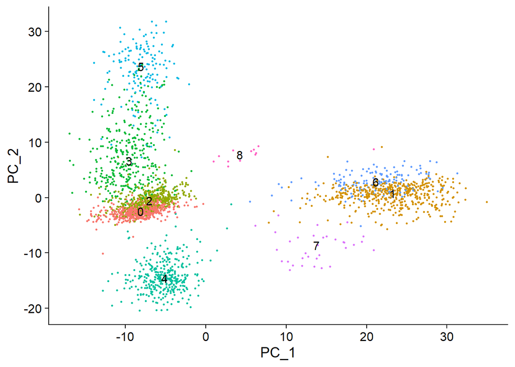

```r
DimPlot(pbmc, reduction = "pca", label = TRUE) + NoLegend()
```

### Run non-linear dimensional reduction (UMAP/tSNE)

Seurat offers several non-linear dimensionality reduction techniques, such as tSNE and UMAP, to visualize and explore these datasets. The goal of these algorithms is to learn the underlying manifold of the data in order to place similar cells together in low-dimensional space. Cells within the graph-based clusters determined above should co-localize on these dimension reduction plots. As input to the UMAP and tSNE, we suggest using the same PCs as input to the clustering analysis.

```r
# In Seurat v3.1.2, RunUMAP calls `uwot` (umap implementation in R and it should be already installed) as default. If RunUMAP does not find R umap, then you can try Python umap via reticulate::py_install(packages = 'umap-learn')
pbmc <- RunUMAP(pbmc, dims = 1:13)
```

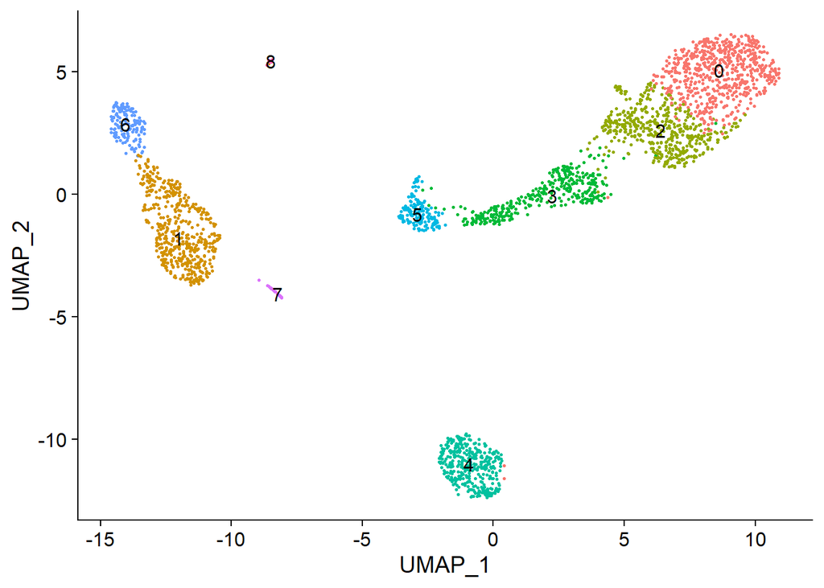

```r
# note that you can set `label = TRUE` or use the LabelClusters function to help label
# individual clusters
DimPlot(pbmc, reduction = "umap", label = TRUE) + NoLegend()
```

Let us save the R variable so that we can contine to work.

```r
save(pbmc, file = "filtered_gene_bc_matrices/hg19/02_pbmc3k_cluster.rd",compress = TRUE)
```

### Three things you need to understand

- PCA
- Clustering
- UMAP